# Cell-type specific analysis and ChromHMM enrichment of cis-meQTLs: Genotype with missingness. LD clumped results

Dexamethasone-Stimulated Human Array Project

Anastasiia Hryhorzhevska

Max Planck Institute of Psychiatry  
anastasiia_hry@psych.mpg.de

Last compiled on 27 November, 2022

# Introduction

## meQTL analysis

This markdown provides comparison between two meQTL analysis after LD clumping. meQTL analysis were done using the R package *MatrixEQTL*. LD clumping was done using PLINK

The imputed QC **SNP data** (no LD pruning, the MHC regions are included) were used. The data includes **3’957’338 SNPs**.

All meQTLs passed the significance threshold of FDR = 0.05.

LD clumping was done per CpG using the following parameters:

–clump-p1 = 0.05: Significance threshold for index SNPs

–clump-p2 = 1: Secondary significance threshold for clumped SNPs

–clump-r2 = 0.2: LD threshold for clumping

–clump-kb = 200: Physical distance threshold for clumping

## Cell-type specific analysis

1. Find the associations between baseline/dex-GR-response CpGs and 12 blood cell types using linear model and adjusting for covariates
2. Adjust for multiple testing correction and extract associations at FDR $\leq$ 0.05
3. Get intersected CpGs between baseline and dex-GR-response CpGs which were obtained at set 2.
4. Extract delta GR-response meQTL CpGs from intersection from step 3.

# Baseline vs GR-response (post-dex)

Number of unique delta GR-response meQTL CpGs among CpGs from dex from cell-type specific analysis: `145320`

Number of unique delta GR-response meQTL CpGs among CpGs from baseline from cell-type specific analysis: `292593`

Number of intesecting CpGs: `108679`

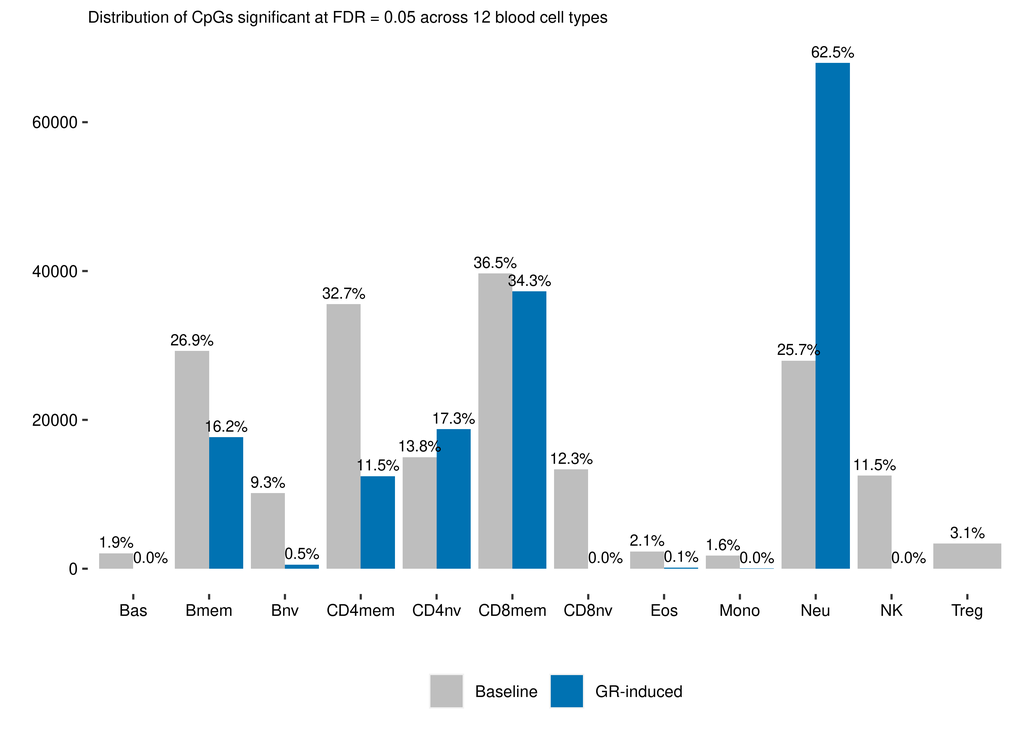

```r
plt.size <- 8

ggplot(bcc.fdr.df, aes(x = Type, fill = Treatment)) +
  geom_bar(stat = "count", alpha = 1, position = position_dodge(width = .9)) +
  geom_text(aes(label = scales::percent(stat(count) / length(intersect.cpgs), accuracy = 0.1)),
            stat = "count", vjust = -0.5, size = plt.size / 3, position = position_dodge(width = 0.9)) +
  theme(legend.position = "bottom", # c(0.9, 0.9),
        legend.title = element_blank(),
        legend.text = element_text(size = plt.size),
        panel.grid.major = element_blank(),
        panel.background = element_blank(),
        plot.title = element_text(size = plt.size),
        axis.title = element_text(size = plt.size),
        axis.text = element_text(size = plt.size, colour = "black")) +
  labs(title = "Distribution of CpGs significant at FDR = 0.05 across 12 blood cell types",
       x = "", y = "") +
  scale_fill_manual(values = cbPalette)
```

## Distribution of DNAm values across blood cell types

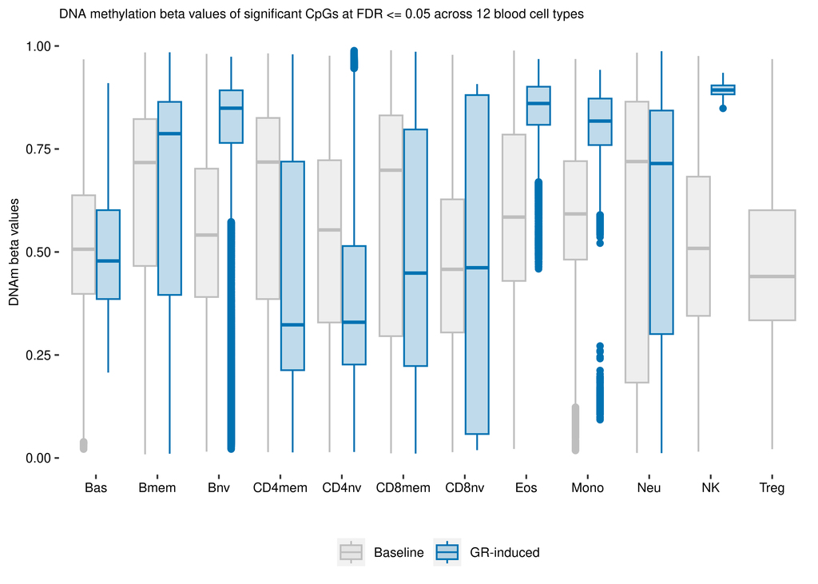

```r
plt.size <- 8

ggplot(dnam.subset, aes(x = Type, y = value, color = Treatment, fill = Treatment)) +
  geom_boxplot(position = position_dodge(width = 0.8)) +
  theme(legend.position = "bottom", # c(0.9, 0.9),
        legend.title = element_blank(),
        legend.text = element_text(size = plt.size),
        panel.grid.major = element_blank(),
        panel.background = element_blank(),
        plot.title = element_text(size = plt.size),
        axis.title = element_text(size = plt.size),
        axis.text = element_text(size = plt.size, colour = "black")) +
  labs(title = "DNA methylation beta values of significant CpGs at FDR <= 0.05 across 12 blood cell types",
       x = "", y = "DNAm beta values") +
  scale_color_manual(values = cbPalette) +
  scale_fill_manual(values = alpha(cbPalette, 0.25))
```

# Cell-type specificity on GR-induced (delta)-meQTLs

Number of unique delta GR-response meQTL CpGs among CpGs from dex from cell-type specific analysis: `453`

Number of unique delta GR-response meQTL CpGs among CpGs from baseline from cell-type specific analysis: `1056`

Number of intesecting CpGs: `385`

Distribution of delta GR-response meQTL CpGs significant at FDR = 0.05 across 12 blood cell types. Percentage describes the CpG ration within a blood cell type to all meQTL CpGs in intersection between baseline and GR-response. Asterisk indicates the significance between GR-response and baseline for each blood cell type based on Kolmogorov-Smirnov test.

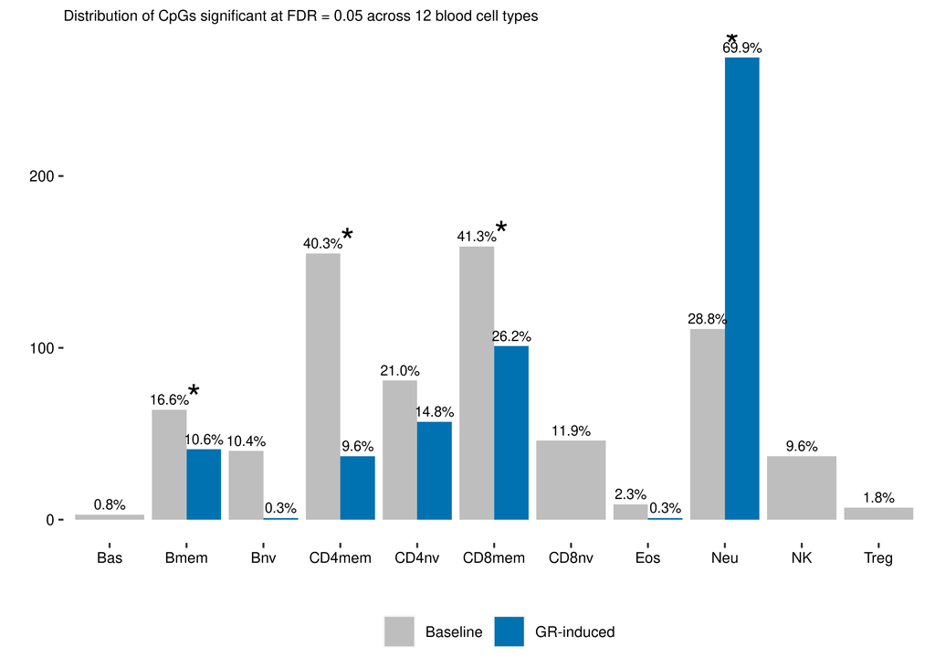

```r
plt.size <- 8

sign.df <- subset(delta.meqtl.bcc.fdr.df, p.value <= 0.05) %>%
  group_by(Type, Treatment) %>%
  tally() %>%
  filter(n == max(n))

ggplot(delta.meqtl.bcc.fdr.df, aes(x = Type, fill = Treatment)) +
  geom_bar(stat = "count", alpha = 1, position = position_dodge(width = .9)) +
  geom_text(aes(label = scales::percent(stat(count) / length(intersect.cpgs), accuracy = 0.1)),
            stat = "count", vjust = -0.5, size = plt.size / 3, position = position_dodge(width = 0.9)) +
  geom_text(data = sign.df,
            aes(y = n, label = "*"), stat = "identity", vjust = 0.05, hjust = 0, size = plt.size - 1) +
  theme(legend.position = "bottom", # c(0.9, 0.9),
        legend.title = element_blank(),
        legend.text = element_text(size = plt.size),
        panel.grid.major = element_blank(),
        panel.background = element_blank(),
        plot.title = element_text(size = plt.size),
        axis.title = element_text(size = plt.size),
        axis.text = element_text(size = plt.size, colour = "black")) +
  labs(title = "Distribution of CpGs significant at FDR = 0.05 across 12 blood cell types",
       x = "", y = "") +
  scale_fill_manual(values = cbPalette)
```

## Distribution of DNAm values across blood cell types

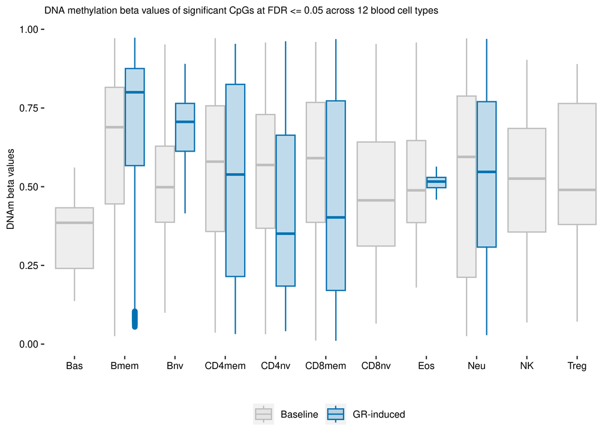

```r
plt.size <- 8

ggplot(dnam.subset, aes(x = Type, y = value, color = Treatment, fill = Treatment)) +
  geom_boxplot(position = position_dodge(width = 0.8)) +
  theme(legend.position = "bottom", # c(0.9, 0.9),
        legend.title = element_blank(),
        legend.text = element_text(size = plt.size),
        panel.grid.major = element_blank(),
        panel.background = element_blank(),
        plot.title = element_text(size = plt.size),
        axis.title = element_text(size = plt.size),
        axis.text = element_text(size = plt.size, colour = "black")) +
  labs(title = "DNA methylation beta values of significant CpGs at FDR <= 0.05 across 12 blood cell types",
       x = "", y = "DNAm beta values") +
  scale_color_manual(values = cbPalette) +
  scale_fill_manual(values = alpha(cbPalette, 0.25))
```

# ChromHMM enrichment

## GR-induced (delta)-meQTLs CpGs

### Blood

Histone mark enrichment for the GR-induced meCpGs using 15 chromatin states from 18 blood and T- & B-cells types. The first figure denotes the fold enrichment / depletion as compared to baseline meCpGs, the second figure denotes significance based on the empirical P≤0.05 with 1,000 permutations.

```r
tissue <- "blood"

enrichment.rslts.fn <- paste0(out.dir.pre, "enrichment/cpgs/meqtl_cpgs_chromHMM_", tissue, "/", list.files(paste0(out.dir.pre,
    "enrichment/cpgs/meqtl_cpgs_chromHMM_", tissue)))

pptx.template <- read_pptx(paste0(dir.pre, "output/plots/meqtls/enrichment/meqtl_snp_chromHMM_enrichment.pptx"))
pptx.out <- paste0(dir.pre, "output/plots/meqtls/enrichment/cpgs/meqtl_cpg_chromHMM_", tissue, "_enrichment.pptx")

enrich.plts <- SavePPTXChromHMMEnrichmentPlot(enrichment.rslts.fn, tissue, epigenome, pptx.template,
    pptx.out, plt.txt.size = 12)
```

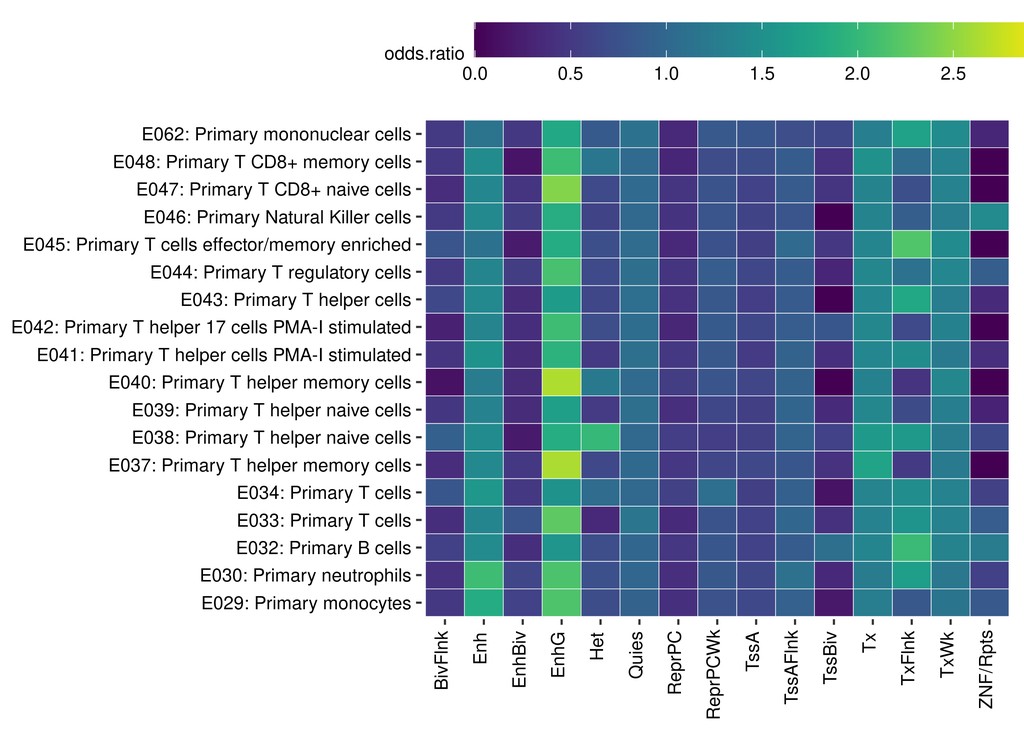

The figure denotes the fold enrichment / depletion as compared to baseline meCpGs

```r
enrich.plts$or
```

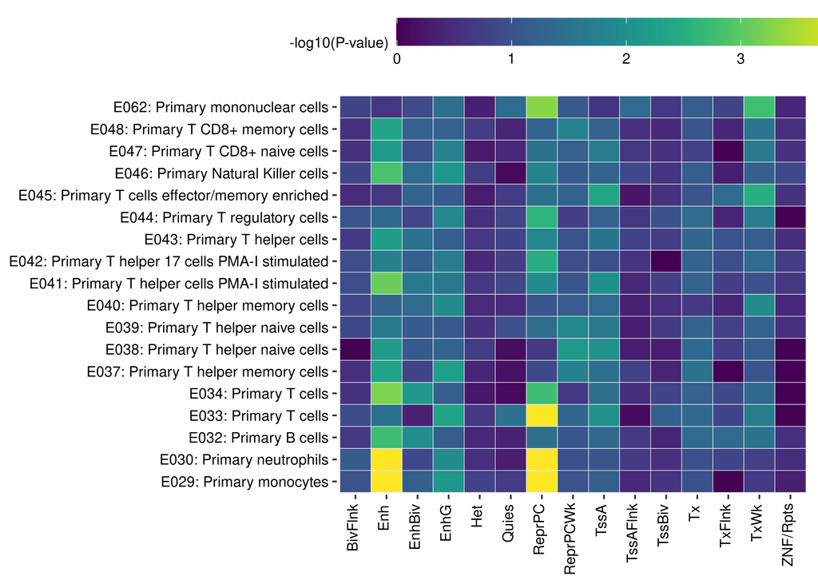

The figure denotes significance based on the empirical P≤0.05 with 1,000 permutations

```r
enrich.plts$pval
```

# IDEAS Enrichment

## Blood

Histone mark enrichment for the GR-induced meCpGs using condensed annotation of 20 chromatin states from 18 blood and T- & B-cells types. The first figure denotes the fold enrichment / depletion as compared to baseline meCpGs, the second figure denotes significance based on the empirical P≤0.05 with 1,000 permutations.

```r
tissue <- "blood"

enrichment.rslts.fn <- paste0(out.dir.pre, "enrichment/cpgs/meqtl_cpgs_IDEAS_", tissue, "/", list.files(paste0(out.dir.pre,
    "enrichment/cpgs/meqtl_cpgs_IDEAS_", tissue)))

pptx.template <- read_pptx(paste0(dir.pre, "output/plots/meqtls/enrichment/meqtl_snp_chromHMM_enrichment.pptx"))
pptx.out <- paste0(dir.pre, "output/plots/meqtls/enrichment/meqtl_cpg_IDEAS_", tissue, "_enrichment.pptx")
enrich.plts <- SavePPTXChromHMMEnrichmentPlot(enrichment.rslts.fn, tissue, epigenome, pptx.template,
    pptx.out, plt.txt.size = 12)
```

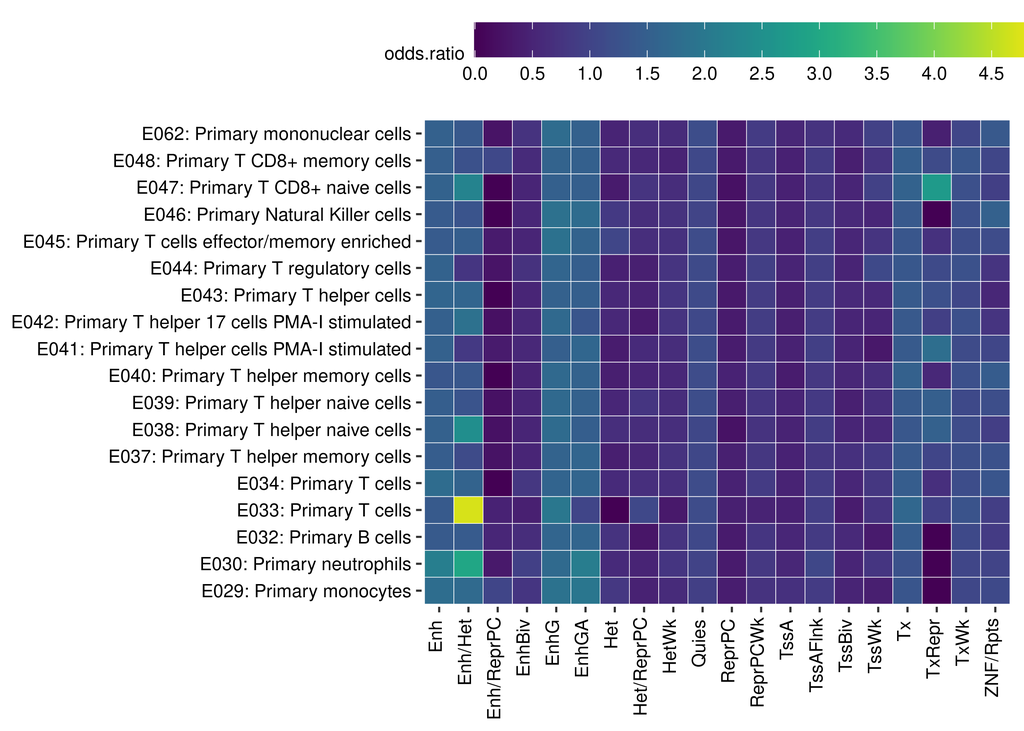

The figure denotes the fold enrichment / depletion as compared to baseline meCpGs

```r
enrich.plts$or
```

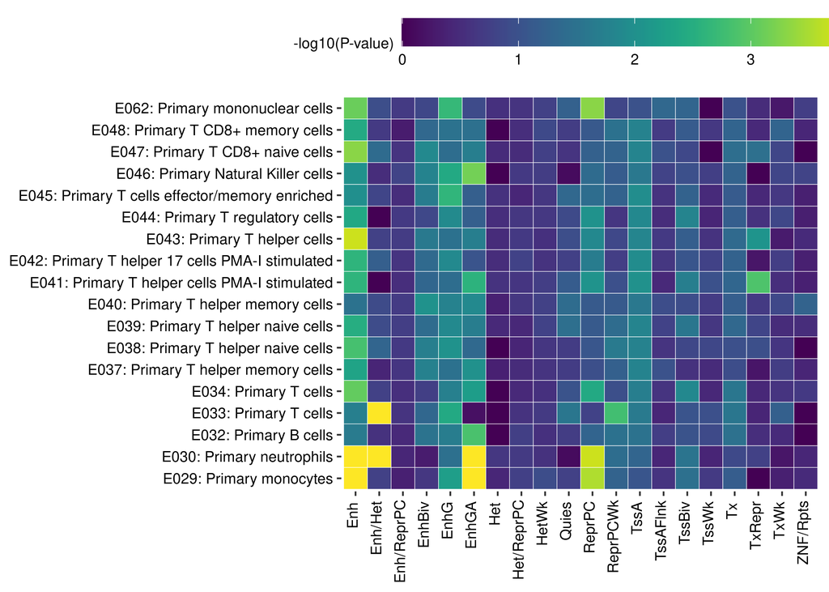

The figure denotes significance based on the empirical P≤0.05 with 1,000 permutations

```r
enrich.plts$pval
```